GIS · Conservation Planning · Western Alberta

# Grizzly Bear Movement Corridor Modelling

Raster Analysis · GDAL · Weighted Cost Surface · Least Cost Path

Joselyne MPAYIMANA | University of British Columbia | 2025

GDAL QGIS ArcGIS Pro Raster Analysis Least Cost Path Weighted Overlay VLCE 2019 ASTER DEM Conservation Planning

## Overview

Grizzly Bears (*Ursus arctos horribilis*) have lost much of their historical range across North America due to habitat fragmentation and human encroachment. The Rocky Mountain foothills of western Alberta now support one of the largest and most studied remaining populations, but connectivity between core and secondary habitat areas remains a critical conservation challenge.

This project builds a least cost path model to identify the optimal movement corridor for Grizzly Bears across the Yellowhead Bear Management Area (BMA) in Alberta. Working entirely from the command line and open geospatial tools, I constructed a multi-factor weighted cost surface from terrain slope, land cover resistance, and proximity to roads, then traced the least costly movement corridor between a core habitat centroid and a randomly selected secondary habitat target using ArcGIS Pro.

20 m

Consistent raster resolution across all layers

3

Cost factors combined in weighted overlay

40%

Weight assigned to land cover as dominant factor

14

ASTER DEM tiles mosaicked for terrain analysis

## Building the Cost Surface

The foundation of this analysis is a carefully constructed cost surface that quantifies the relative difficulty for a Grizzly Bear to traverse each 20 m cell in the study area. Three cost layers were derived independently and then combined using a weighted overlay formula.

### Setting Up the Raster Framework with GDAL

All raster processing was handled from the command line using GDAL utilities, which allowed precise control over cell size, extent alignment, coordinate systems, and resampling methods. The first step was creating a master AOI raster from the Yellowhead BMA boundary to serve as the spatial template for every subsequent layer.

AOI raster creation

```
gdal_rasterize -burn 1 -tr 20 20 -ot Byte -a_nodata nodata -tap yellowhead_bma_utm.shp yellowhead_bma_utm.tif
```

The 14 ASTER DEM tiles covering the study area were then mosaicked and reprojected from WGS84 to NAD83 UTM Zone 11N using cubic resampling, which preserves smooth gradients in continuous elevation data.

DEM reprojection and clipping to AOI extent

```
gdalwarp -s_srs EPSG:4326 -t_srs EPSG:26911 -te 401480 5753440 661680 5936300 -tr 20 20 -r cubic aster_dem_wgs84.tif aster_dem_utm.tif
```

The national land cover dataset (VLCE 2019) required a different approach. Because land cover codes are categorical rather than continuous, nearest neighbor resampling was used to preserve exact integer class values during reprojection.

Land cover reprojection using nearest neighbor to preserve class codes

```
gdalwarp -s_srs EPSG:3978 -t_srs EPSG:26911 -te 401480 5753440 661680 5936300 -tr 20 20 -r near ca_forest_vlce2_2019.tif land_cover_utm.tif
```

### Deriving the Three Cost Layers

Slope Cost

Slope was derived from the DEM and normalized to a 0 to 1 range by dividing by 90 degrees. Steeper terrain costs more energy for bears to traverse and increases movement resistance.

Land Cover Cost

Each VLCE 2019 land cover class was reclassified to a cost value between 0 and 1. Coniferous forest received a cost of 0 as the most permeable habitat. Water and wetlands received costs of 0.9 as the most resistant to movement. Snow/Ice received the maximum cost of 1.0.

Road Distance Cost

Roads were rasterized and a proximity raster was computed. An inverse distance formula was applied so road cells have cost 1 and resistance decreases with distance from the road network, reflecting bear avoidance of human infrastructure.

Inverse distance road cost formula

```
(1 / ("yellowhead_roads_distance_utm@1" + 0.5)) / 2
```

### Land Cover Cost Values

| Land Cover Class | Cost | Rationale |
| --- | --- | --- |
| Coniferous Forest | 0.0 | Optimal bear habitat, lowest movement resistance |
| Bryoids | 0.1 | Open, low vegetation, easy to traverse |
| Shrubs | 0.2 | Moderate vegetation density, passable terrain |
| Treed Wetland | 0.2 | Treed cover reduces physical barrier of wetland |
| Mixedwood Forest | 0.2 | Good habitat quality, easy movement |
| Herbs | 0.3 | Open terrain, may contain food resources |
| Broadleaf Forest | 0.3 | Slightly higher resistance than coniferous |
| Exposed Barren Land | 0.7 | Rocky, dry terrain, energetically demanding |
| Rock / Rubble | 0.8 | High physical resistance, limited bear use |
| Water | 0.9 | Major barrier, high energy cost to cross |
| Wetland | 0.9 | Saturated soils and standing water impede movement |
| Snow / Ice | 1.0 | Maximum resistance, impassable for most movement |

### Weighted Overlay

The three normalized cost layers were combined using a weighted formula. Land cover received the highest weight because habitat type is the primary driver of Grizzly Bear movement decisions. Slope and road distance were weighted equally, reflecting that both terrain difficulty and human disturbance influence movement but are secondary to habitat quality.

Weighted cost surface formula

```
totalcost = (slope × 0.3) + (land_cover × 0.4) + (road_distance × 0.3)
```

Slope 30%

Land Cover 40%

Road Distance 30%

## Least Cost Path Analysis

With the cost surface complete, I moved to ArcGIS Pro to run the least cost path analysis. The Distance Accumulation tool computed the accumulated cost-distance from the source point (centroid of the Yellowhead core habitat area) to every cell in the AOI, incorporating both the cost surface and the real three-dimensional travel distance from the ASTER DEM. The backlink raster encoded the direction of least costly movement back to the source for each cell. Finally, the Optimal Path as Line tool traced the corridor from the secondary habitat target back to the source along the path of minimum accumulated cost.

## Map

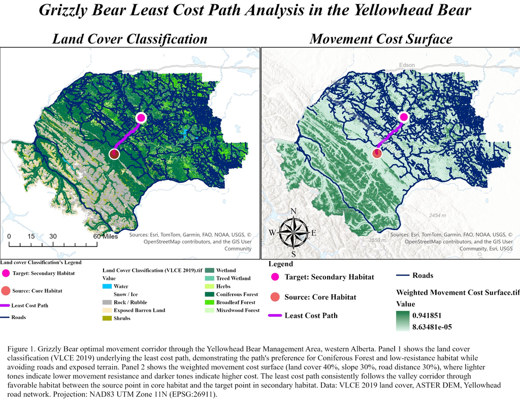

Figure 1. Grizzly Bear optimal movement corridor through the Yellowhead Bear Management Area, western Alberta. Panel 1 shows the land cover classification (VLCE 2019) underlying the least cost path, demonstrating the path's preference for Coniferous Forest and low-resistance habitat while avoiding roads and exposed terrain. Panel 2 shows the weighted movement cost surface (land cover 40%, slope 30%, road distance 30%), where lighter tones indicate lower movement resistance and darker tones indicate higher cost. The path consistently follows the valley corridor through favorable habitat between the source point in core habitat and the target point in secondary habitat. Data: VLCE 2019, ASTER DEM, Yellowhead road network. Projection: NAD83 UTM Zone 11N (EPSG:26911).

## Key Findings

The path shows that bears would accept some initial elevation change near the source area to gain access to a longer stretch of high-quality, low-resistance forest habitat. This is ecologically realistic. Grizzly Bears in the Rocky Mountain foothills are known to preferentially use forested valley corridors, tolerating moderate terrain and occasional road crossings to remain in productive cover. The equal weighting of slope and road distance at 30% each meant neither factor alone was sufficient to redirect the path, but their combined influence shaped the specific route taken through the landscape.

The analysis demonstrates how relatively simple weighted raster operations can generate ecologically meaningful habitat connectivity models. The modelling framework is directly scalable to other species and regions where habitat suitability and movement barrier data are available, making it a practical tool for conservation planners assessing wildlife corridor viability.

Joselyne MPAYIMANA | Master of Geomatics for Environmental Management, UBC | 2025